# Pivoting and Facets

In this notebook we will investigate **pivoting** and **tidy data**.

### Imports

```r
library(tidyverse)
```

One of the key tenets of the tidyverse is its reliance on tidy data. Tidy data has the following rules:

- Each variable must have its own column.
- Each observation must have its own row.
- Each value must have its own cell.

Take a look at the following dataset of energy consumption by sector and fuel:

```r
energy <- read_csv('data/energy_consumption_by_sector_fuel.csv')
```

Which rule(s) of tidy data does the dataset violate?

### Task: use pivot_longer() to make the energy data tidy

```r
longer <- energy %>%
  pivot_longer(Solid_Fuel: Electricity,
               names_to = 'fuel',
               values_to = 'consumption')
```

### Task: create the plot on the right with ggplot2 and geom_line()

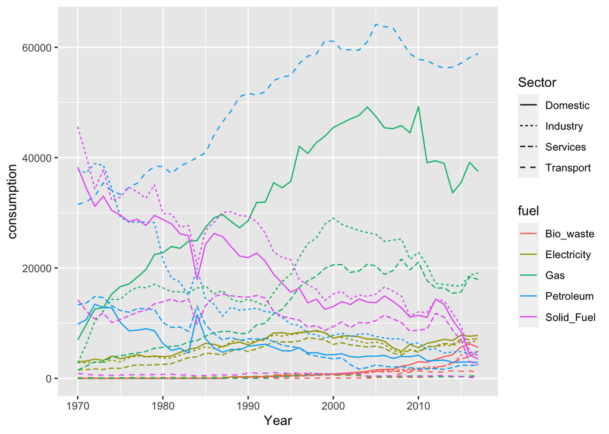

```r
longer %>%
  ggplot() +
  geom_line(aes(x = Year,
                y = consumption,
                color = fuel,
                linetype = Sector))
```

### Task: use pivot_wider() to return the pivoted energy data frame back to its original

```r
longer %>%
  pivot_wider(names_from = fuel, values_from = consumption)
```

| Year | Sector | Solid_Fuel | Petroleum | Gas | Bio_waste | Electricity |
| --- | --- | --- | --- | --- | --- | --- |
| 1970 | Industry | 45572.6655 | 37757.669 | 2808.246638 | 0.000000 | 2820.37390 |
| 1970 | Transport | 899.3121 | 31514.548 | 1.226746 | 0.000000 | 106.52249 |
| 1970 | Domestic | 38261.9731 | 9797.976 | 6979.141058 | 0.000000 | 2976.33720 |
| 1970 | Services | 14260.0493 | 13295.505 | 1511.385558 | 0.000000 | 1531.76641 |
| 1971 | Industry | 40284.4589 | 37249.993 | 6219.172153 | 0.000000 | 2845.50473 |
| 1971 | Transport | 745.0471 | 31998.035 | 8.566702 | 0.000000 | 106.82475 |
| 1971 | Domestic | 34486.1092 | 10647.947 | 9767.869028 | 0.000000 | 3126.76482 |
| 1971 | Services | 12216.3848 | 13646.540 | 2224.392117 | 0.000000 | 1592.90570 |
| 1972 | Industry | 34345.4298 | 38943.884 | 10297.121760 | 0.000000 | 2925.42515 |
| 1972 | Transport | 583.9768 | 33013.541 | 21.814443 | 0.000000 | 106.47209 |

[output cut: 182 more lines]

### Task: use pivot_wider() to create a new data frame with the following columns: Sector, fuel, 1970, 1971,…2017

```r
longer %>%
  pivot_wider(names_from = Year, values_from = consumption)
```

| Sector | fuel | 1970 | 1971 | 1972 | 1973 | 1974 | 1975 | 1976 | 1977 | 1978 | 1979 | 1980 | 1981 | 1982 | 1983 | 1984 | 1985 | 1986 | 1987 | 1988 | 1989 | 1990 | 1991 | 1992 | 1993 | 1994 | 1995 | 1996 | 1997 | … |
| --- | --- | --- | --- | --- | --- | --- | --- | --- | --- | --- | --- | --- | --- | --- | --- | --- | --- | --- | --- | --- | --- | --- | --- | --- | --- | --- | --- | --- | --- | --- |
| Industry | Solid_Fuel | 45572.665520 | 40284.458880 | 34345.42975 | 37748.266160 | 32205.73710 | 32821.61333 | 34643.83699 | 33782.70758 | 32615.14499 | 35081.313320 | 29876.730680 | 29785.057200 | 27398.568170 | 27702.112600 | 20630.520270 | 26816.057330 | 28328.879270 | 30097.270940 | 30179.416550 | 29512.505630 | 29376.330470 | 28410.664670 | 26333.540460 | 22902.43298 | 21891.4660 | 21521.98857 | 17844.54860 | 17030.04398 | … |
| Industry | Petroleum | 37757.668560 | 37249.992630 | 38943.88361 | 38626.321900 | 34361.77116 | 29229.04895 | 28289.52140 | 28333.05598 | 28332.15130 | 28197.239810 | 21385.934820 | 18146.691290 | 17448.818530 | 14981.695280 | 19957.351690 | 14441.001960 | 13415.130940 | 11274.346620 | 12891.228380 | 12352.138320 | 12506.518870 | 12695.330110 | 12115.608430 | 11912.17589 | 11022.6079 | 9837.31377 | 9616.76650 | 8107.90428 | … |
| Industry | Gas | 2808.246638 | 6219.172153 | 10297.12176 | 12203.909010 | 14297.12603 | 14314.91262 | 15684.64387 | 16569.05447 | 16401.74800 | 17028.763500 | 16387.259320 | 15714.003600 | 15678.350240 | 15617.264080 | 16350.077250 | 16760.817860 | 15299.808540 | 15906.986000 | 14385.704690 | 13777.354440 | 14379.269260 | 13788.157190 | 13138.333180 | 15540.23928 | 17540.9496 | 18819.65991 | 21907.65618 | 24444.36645 | … |
| Industry | Bio_waste | 0.000000 | 0.000000 | 0.00000 | 0.000000 | 0.00000 | 0.00000 | 0.00000 | 0.00000 | 0.00000 | 0.000000 | 0.000000 | 0.000000 | 0.000000 | 0.000000 | 0.000000 | 0.000000 | 0.000000 | 0.000000 | 175.006450 | 188.633280 | 182.583549 | 191.963488 | 320.747589 | 444.40402 | 742.2387 | 811.52227 | 759.82780 | 958.94676 | … |
| Industry | Electricity | 2820.373897 | 2845.504729 | 2925.42515 | 2840.223727 | 3311.04500 | 2993.87673 | 3730.88688 | 4084.47166 | 3847.42563 | 3944.203086 | 3648.085290 | 3692.520876 | 4199.748048 | 4688.672889 | 5203.449689 | 5726.726663 | 5367.484275 | 5682.499551 | 6619.308667 | 7072.667068 | 6503.076776 | 6816.388912 | 6891.747748 | 7921.53322 | 7661.8541 | 7913.78753 | 8112.97843 | 8571.60044 | … |
| Transport | Solid_Fuel | 899.312117 | 745.047120 | 583.97685 | 596.856669 | 551.82271 | 611.77596 | 640.77966 | 654.47481 | 657.87464 | 686.464250 | 730.189155 | 733.044471 | 612.758370 | 641.475518 | 409.928786 | 545.413917 | 602.813238 | 616.345746 | 622.442800 | 584.880353 | 975.312962 | 952.534217 | 911.141646 | 1047.92361 | 920.6436 | 924.60117 | 960.99202 | 823.51561 | … |
| Transport | Petroleum | 31514.548420 | 31998.035090 | 33013.54145 | 35424.770640 | 34036.21365 | 33318.52879 | 34604.48221 | 35384.36473 | 37273.09001 | 38391.344820 | 38422.744310 | 37101.886030 | 38482.950710 | 39142.984940 | 40045.393420 | 40885.589540 | 44116.817040 | 46460.217070 | 48474.521680 | 51042.351580 | 51659.587660 | 51354.881570 | 51920.059670 | 53957.70848 | 54642.0895 | 54864.47742 | 57089.42170 | 58397.43912 | … |
| Transport | Gas | 1.226746 | 8.566702 | 21.81444 | 7.837594 | 32.75678 | 30.80778 | 22.56941 | 18.26064 | 11.96571 | 7.272105 | 6.074099 | 3.095214 | 2.768514 | 3.047506 | 5.928943 | 7.592025 | 2.525107 | 2.523671 | 13.031157 | 6.844853 | 11.855542 | 11.797796 | 32.377568 | 204.97545 | 268.3777 | 364.81529 | 510.42124 | 648.36316 | … |
| Transport | Bio_waste | 0.000000 | 0.000000 | 0.00000 | 0.000000 | 0.00000 | 0.00000 | 0.00000 | 0.00000 | 0.00000 | 0.000000 | 0.000000 | 0.000000 | 0.000000 | 0.000000 | 0.000000 | 0.000000 | 0.000000 | 0.000000 | 2.521941 | 3.014654 | 4.124614 | 4.537972 | 5.216129 | 12.31736 | 15.0066 | 16.52369 | 17.36708 | 25.06257 | … |
| Transport | Electricity | 106.522488 | 106.824746 | 106.47209 | 92.418669 | 118.88669 | 115.06024 | 132.59411 | 145.93604 | 135.31516 | 133.097859 | 139.451174 | 144.422064 | 151.383961 | 181.634599 | 190.182313 | 212.752461 | 201.943409 | 187.405357 | 223.550305 | 225.001806 | 341.871743 | 361.396773 | 387.734405 | 609.71455 | 567.8608 | 581.57035 | 639.36681 | 680.18389 | … |

[output cut: 10 more lines]

### Task: use facet_wrap() to create a bar plot for each sector (see right)

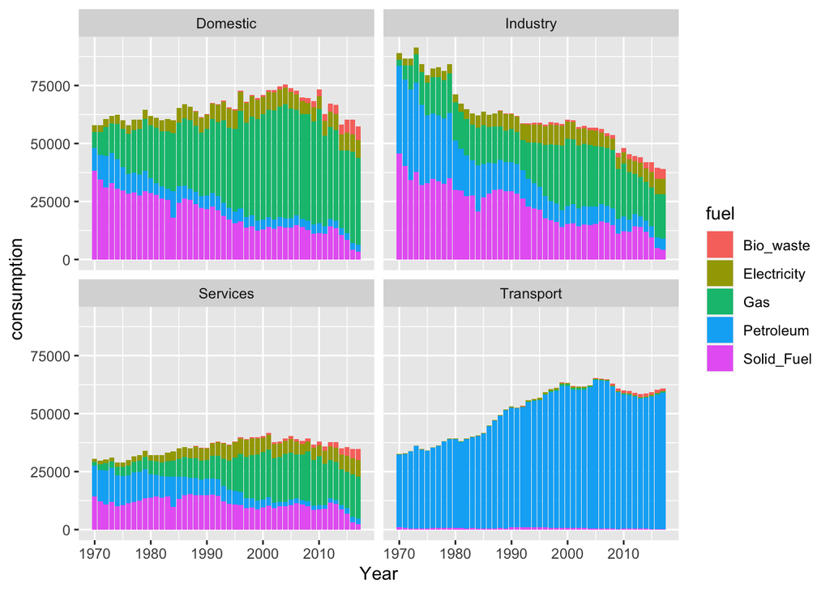

```r
# Creating the base plot
plot <- longer %>%
  ggplot() +
  geom_col(aes(x = Year,
               y = consumption,
               fill = fuel))

plot + facet_wrap(~Sector)
```

### Task: use the `scales` argument to allow each panel to be freely scaled by consumption

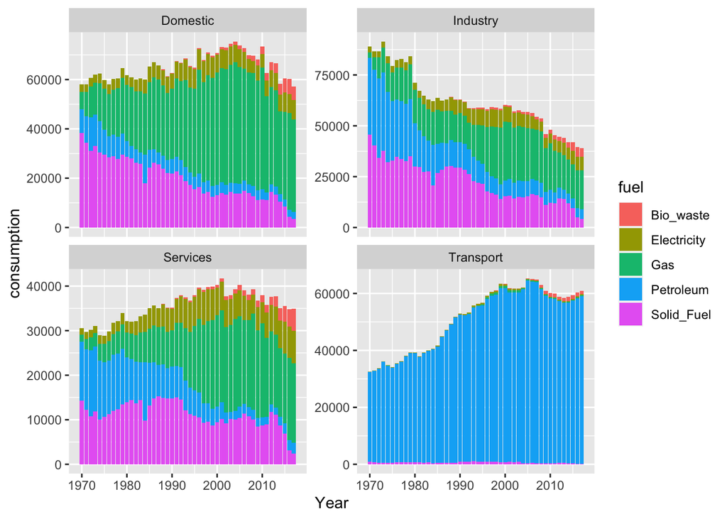

```r
plot + facet_wrap(~Sector, scales = 'free_y')
```

### Task: create a bar plot of consumption vs. year, coloured by Sector, faceted by fuel

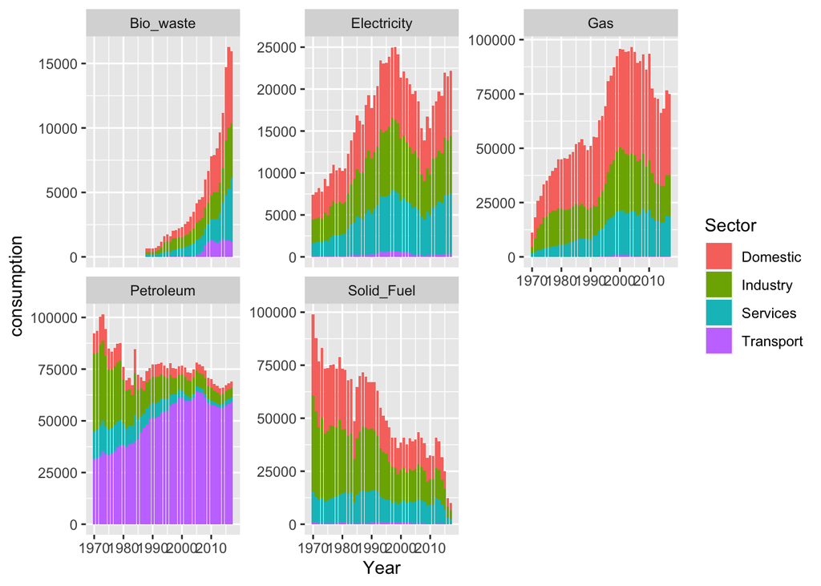

```r
longer %>%
  ggplot() +
  geom_col(aes(x = Year,
               y = consumption,
               fill = Sector)) +
  facet_wrap(~fuel, scales = 'free_y')
```

### Task: use facet_grid() to create a line plot for each fuel and sector (see right)

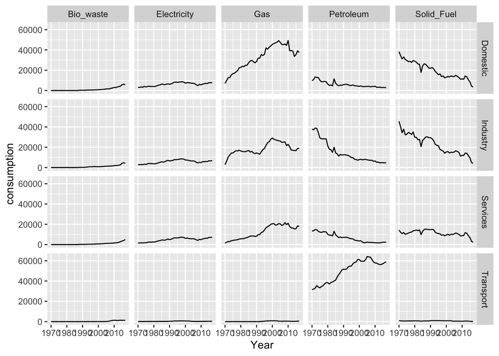

```r
longer %>%
  ggplot() +
  geom_line(aes(x = Year,
               y = consumption)) +
  facet_grid(Sector ~ fuel)
```

### Task: replace facet_grid() with facet_wrap() and set the y scale to be free

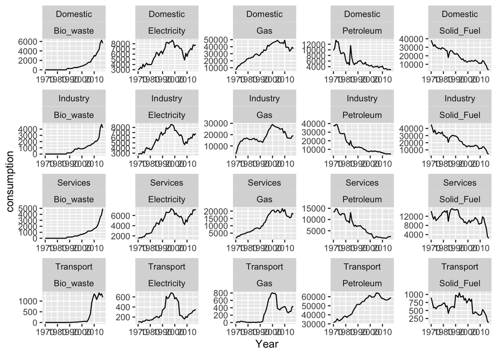

```r
longer %>%
  ggplot() +
  geom_line(aes(x = Year,
                y = consumption)) +
  facet_wrap(Sector ~ fuel, scales = 'free')
```